# Assisting children while biking

### Gruppe 7: Maximilian Hörnis, Florian Schwarm, Dennis Rupprecht

## Motivation

- Children are active participants in road traffic
- Traffic signs might not be obvious to them
- Handheld technology device (smartphones etc.) usage is prevalent among children

## Idea

Recognize and classify traffic signs automatically and display them in an easy to understand assistive technology for children, without distracting them.

## Tasks

- Recognizing and classifiying traffic signs
- Interpretation of images in a way that is
  - a) sufficiently comprehensible for children and
  - b) not distracting.

## Possible Extensions

- Detection of intersections without relying on traffic signs
- Detection of traffic lights and their current position (red, green, yellow)
- Applying the traffic sign classifier to live video (or recordings)
- Integrating the system into a mobile application

## Possible Issues

- Recognizing dirty or occluded signs
- Determining which street a sign refers to and how long it is valid
- Reliable detection of intersections

```python
# Import some libs
import matplotlib
import cv2
import matplotlib.pyplot as plt
import numpy as np
```

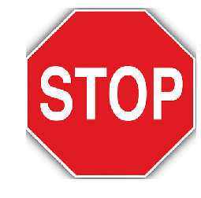

```python
# Show a image
img = cv2.imread('img/stopsign.png')
img = cv2.cvtColor(img, cv2.COLOR_BGR2RGB)
fig = plt.figure()
plt.axis("off")
plt.imshow(img)
```

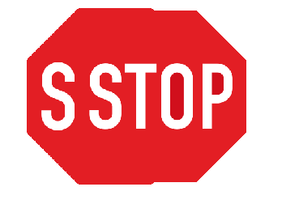

```python
# Show a image with transparence
img2 = cv2.imread('img/stopsign2.png', cv2.IMREAD_UNCHANGED)
# After the next step, the image is not as before.
img2 = cv2.cvtColor(img2, cv2.COLOR_BGR2RGB)
plt.axis("off")
plt.imshow(img2)
```

[figure not shown]

```python
# Define the colors. We are looking for the colors between [224, 27, 34](color img) and [227, 30, 36](color img2)
lower = np.array([224, 27, 34], dtype = "uint8")
upper = np.array([227, 30, 36], dtype = "uint8")
# inRange now looking in the picture between the both colors
mask = cv2.inRange(img, lower, upper)
plt.axis("off")
plt.imshow(mask)
```

[figure not shown]

```python
# bitwise_and show only the selected origin colors. Other colors are black
output = cv2.bitwise_and(img, img, mask = mask)
plt.axis("off")
plt.imshow(output)
```

[figure not shown]

```python
# the same with img2
mask2 = cv2.inRange(img2, lower, upper)
plt.axis("off")
plt.imshow(mask2)
```

[figure not shown]

```python
# bitwise_and show only the selected origin colors. Other colors are black
output2 = cv2.bitwise_and(img2, img2, mask = mask2)
plt.axis("off")
plt.imshow(output2)
```

[figure not shown]

```python
lower2 = np.array([200, 15, 28], dtype = "uint8")
upper2 = np.array([227, 30, 36], dtype = "uint8")
mask = cv2.inRange(img, lower2, upper2)
output = cv2.bitwise_and(img, img, mask = mask)
plt.axis("off")
plt.imshow(output)
```

[figure not shown]

```python
mask2 = cv2.inRange(img2, lower2, upper2)
output2 = cv2.bitwise_and(img2, img2, mask = mask2)
plt.axis("off")
plt.imshow(output2)
```

[figure not shown]

```python
lower3 = np.array([200, 15, 28], dtype = "uint8")
upper3 = np.array([227, 50, 65], dtype = "uint8")
mask = cv2.inRange(img, lower3, upper3)
output = cv2.bitwise_and(img, img, mask = mask)
plt.axis("off")
plt.imshow(output)
```

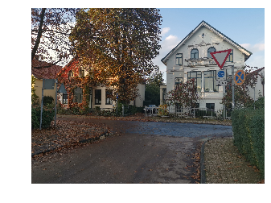

```python
sel_img = cv2.imread('img/selBild_1.jpg', cv2.IMREAD_UNCHANGED)
sel_img = cv2.cvtColor(sel_img, cv2.COLOR_BGR2RGB)
plt.axis("off")
plt.imshow(sel_img)
```

[figure not shown]

```python
mask3 = cv2.inRange(sel_img, lower3, upper3)
output3 = cv2.bitwise_and(sel_img, sel_img, mask = mask3)
plt.axis("off")
plt.imshow(output3)
```

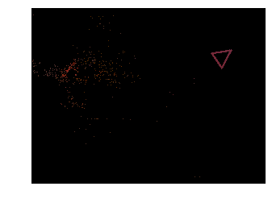

```python
lower4 = np.array([78, 0, 0], dtype = "uint8")
upper4 = np.array([255, 50, 65], dtype = "uint8")
mask4 = cv2.inRange(sel_img, lower4, upper4)
output4 = cv2.bitwise_and(sel_img, sel_img, mask = mask4)
plt.axis("off")
plt.imshow(output4)
```

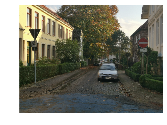

```python
sel_img_2 = cv2.imread('img/selBild_3.jpg', cv2.IMREAD_UNCHANGED)
sel_img_2 = cv2.cvtColor(sel_img_2, cv2.COLOR_BGR2RGB)
plt.axis("off")
plt.imshow(sel_img_2)
```

[figure not shown]

```python
mask5 = cv2.inRange(sel_img_2, lower4, upper4)
output5 = cv2.bitwise_and(sel_img_2, sel_img_2, mask = mask5)
plt.axis("off")
plt.imshow(output5)
```

[output not shown]

### Zusammenfassung

- Farberkennung ist möglich
- Muster müssen aus diesen Farben nun überprüft werden
- leichte Störungen sind in einzelnenBildern zu sehen
- Maximum und Minimum müssen genau ausgearbeitet werden
  - Möglich mit verschiedenen Maximum und Minimumwerten
- Problem: Licht

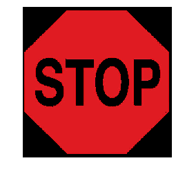

```python
mask = cv2.inRange(img, lower4, upper4)
output = cv2.bitwise_and(img, img, mask = mask)
plt.axis("off")
plt.imshow(output)
```